# Splean Song Lyrics Semantic Similarity

Yashchenko Anastasia, Krasnov Stanislav

19 июня 2018 г

Our corpus-based study investigates the value of word frequency in text clustering. We have chosen a corpus of song lyrics in order to show how lexical diversity and word repetition influence the similarity between two given songs and, furthermore, albums.

### Hypothesis

Lyrics within one album are connected with lyrics within another album and this connection is based on song word frequency.

### Pre-processing

Using Python: converting to lower-case, removing punctuation + lemmatization.  
Using R: removing stop-words.  
We used Python for lemmatization as it is a usual way for us, since we were not aware of any efficient tool for lemmatization of russian texts in R.

Loading data and libraries, removing stop words, using tidytext library:

```r
splean <- read.csv("DATA.csv",
                      encoding = "UTF-8",
                      stringsAsFactors = FALSE)
newstops <- c(stopwords('ru'), c('весь', 'свой', 'твой'))
remove_w <- function(x) removeWords(x, newstops)
splean$text <- sapply(splean$text, remove_w)
```

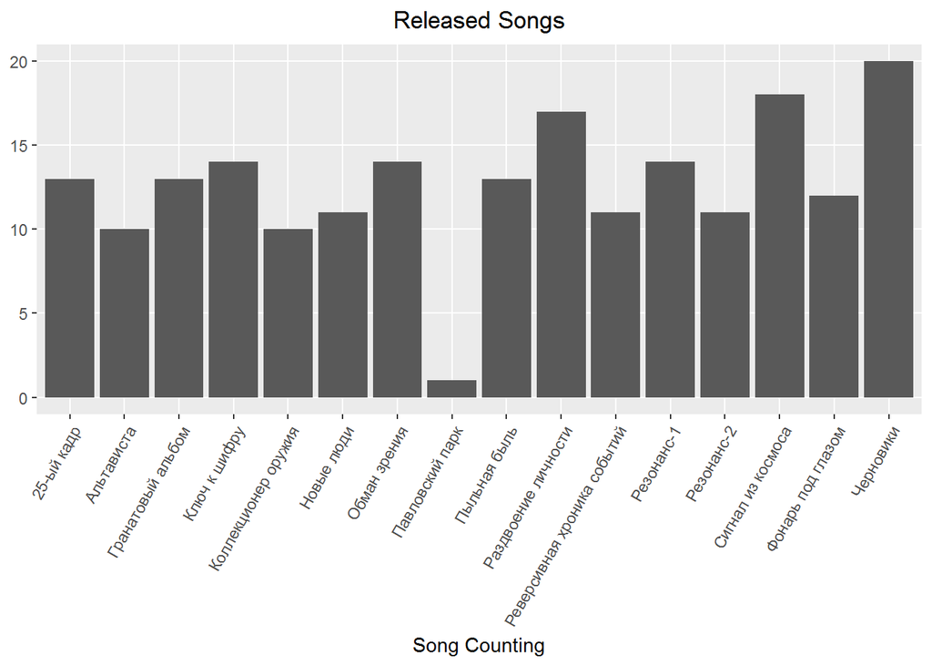

```r
splean %>%
  group_by(album) %>%
  summarise(number_of_songs = n()) %>%
  ggplot() +
  geom_bar(aes(x = album, y = number_of_songs), stat = "identity")  +
  theme(plot.title = element_text(hjust = 0.5),
        legend.title = element_blank(),
        axis.text.x = element_text(angle=60, hjust=1),
        panel.grid.minor = element_blank()) +
  ggtitle("Released Songs") +
  labs(x = "Song Counting", y = NULL)
```

```r
splean_words <- splean %>%
  unnest_tokens(word, text) %>%
  distinct() %>%
  filter(nchar(word) > 3)
word_count <- splean_words %>%
  group_by(album,song_title) %>%
  summarise(num_words = n())
```

Now let us visualize the most common words for splean lyrics:

```r
words_freq <- splean_words %>%
  count(word, sort = TRUE)
wordcloud2(words_freq[1:300, ], size = .5)
```

[interactive chart not shown]

Our data have the information on the album of a given song, so we use it to show the most frequent words for each album:

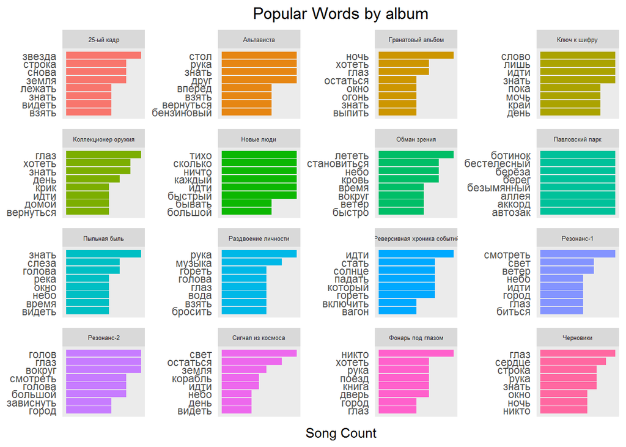

```r
theme_lyrics <- function()
{
  theme(plot.title = element_text(hjust = 0.5),
        axis.text.x = element_blank(),
        axis.ticks = element_blank(),
        panel.grid.major = element_blank(),
        panel.grid.minor = element_blank(),
        strip.text = element_text(size=5),
        legend.position = "none")
}
album_words <- splean_words %>%
  group_by(album) %>%
  count(word, album, sort = TRUE) %>%
  slice(seq_len(8)) %>%
  ungroup() %>%
  arrange(album,n) %>%
  mutate(row = row_number())
album_words %>%
  ggplot(aes(row, n, fill = album)) +
  geom_col() +
  labs(x = NULL, y = "Song Count") +
  ggtitle("Popular Words by album") +
  theme_lyrics() +
  facet_wrap(~album, scales = "free") +
  scale_x_continuous(
    breaks = album_words$row,
    labels = album_words$word) +
  coord_flip()
```

As we can see, in the album ‘Павловский парк’ the set of popular words is rather different from other albums (due to the fact ‘Павловский парк’ consists of only one song).

## More parameters

Since we are dealing with lyrics analysis, we should have a closer look at such parameters as lexical diversity and lexical density.

### Lexical diversity

Lexical diversity is the number of unique words in a given song.

```r
#LEXICAL DIVERSITY
my_colors <- c("#E69F00", "#56B4E9", "#009E73", "#CC79A7", "#D55E00")
lex_diversity_per_album <- splean_words %>%
  group_by(album,song_title) %>%
  summarise(lex_diversity = n_distinct(word)) %>%
  arrange(desc(lex_diversity))

diversity_plot <- lex_diversity_per_album %>%
  ggplot(aes(album, lex_diversity)) +
  geom_point(color = my_colors[3],
             alpha = .4,
             size = 4,
             position = "jitter") +
  stat_smooth(color = "black", se = FALSE, method = "loess") +
  geom_smooth(aes(x = album, y = lex_diversity), se = FALSE,
              color = "blue", lwd = 2) +
  ggtitle("Lexical Diversity") +
  xlab("") +
  ylab("") +
  scale_color_manual(values = my_colors) +
  theme_classic() +
  theme_lyrics()
```

So, there is one song with a lot of unique words and several songs with above the average LD.

### Lexical density

Lexical density is the measure of word repetition within one song (the number of unique words divided by total word number).

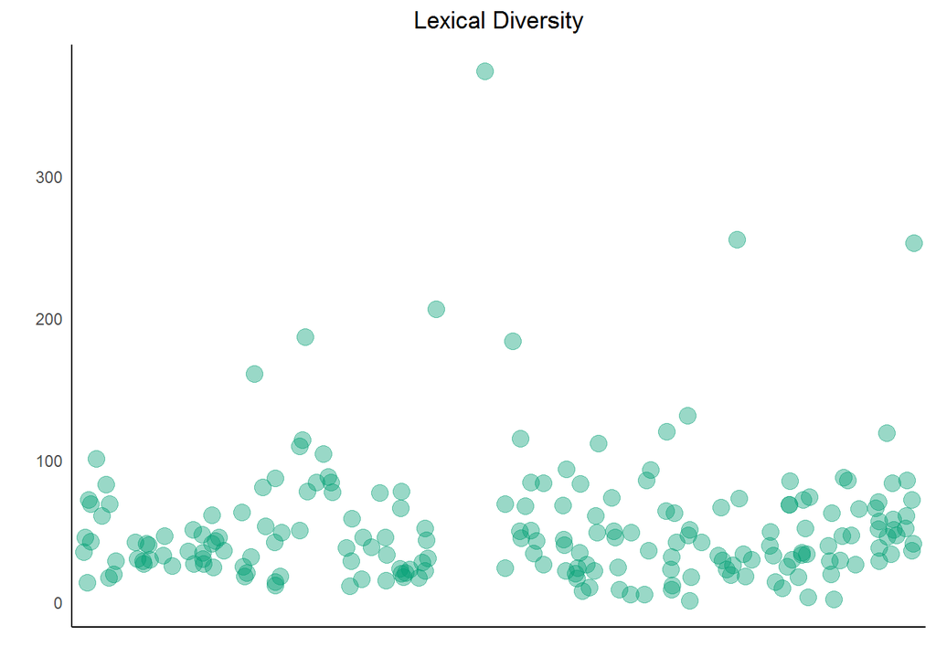

```r
#LEXICAL DENSITY
lex_density_per_album <- splean_words %>%
  group_by(album,song_title) %>%
  summarise(lex_density = n_distinct(word)/n()) %>%
  arrange(desc(lex_density))

density_plot <- lex_density_per_album %>%
  ggplot(aes(album, lex_density)) +
  geom_point(color = my_colors[4],
             alpha = .4,
             size = 4,
             position = "jitter") +
  stat_smooth(color = "black",
              se = FALSE,
              method = "lm") +
  geom_smooth(aes(x = album, y = lex_density),
              se = FALSE,
              color = "blue",
              lwd = 2) +
  ggtitle("Lexical Density") +
  xlab("") +
  ylab("") +
  scale_color_manual(values = my_colors) +
  theme_classic() +
  theme_lyrics()
diversity_plot
```

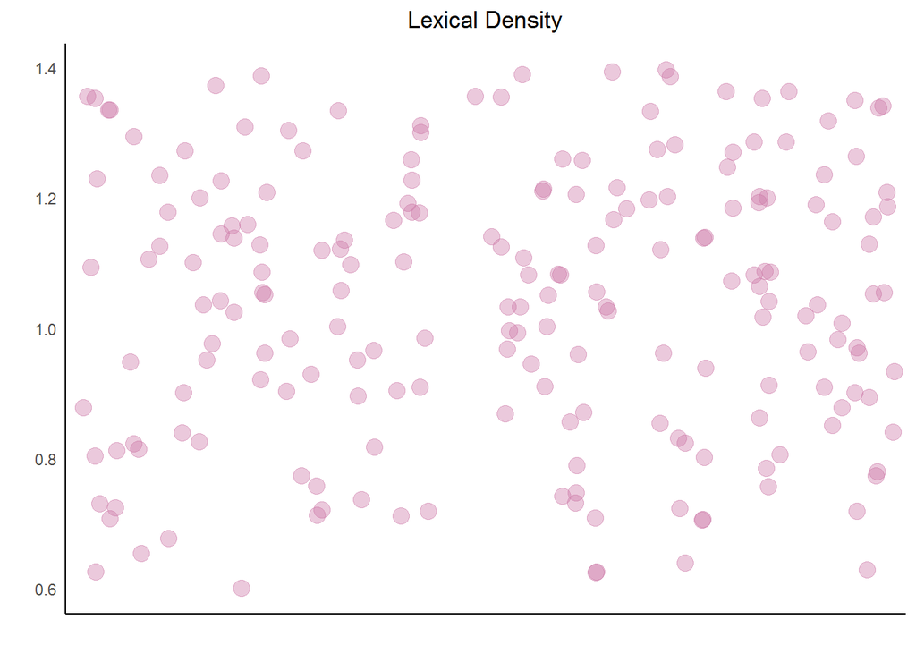

```r
density_plot
```

## Lyrics clustering

Lyrics clustering is based on term frequency throughout the whole corpus. In order to perform text clustering, we convert all songs to document term matrices:

```r
corpus <- VCorpus(VectorSource(splean$text))
dtm <-  DocumentTermMatrix(corpus)
findFreqTerms(dtm, lowfreq=45)
```

```
##  [1] "волна"    "время"    "глаз"     "год"      "голова"   "город"
##  [7] "дать"     "день"     "дом"      "друг"     "знать"    "идти"
## [13] "лететь"   "любовь"   "мир"      "наш"      "небо"     "никто"
## [19] "ночь"     "окно"     "петь"     "пить"     "пока"     "рука"
## [25] "самый"    "свет"     "сердце"   "скоро"    "смотреть" "солнце"
## [31] "уйти"     "хороший"  "хотеть"   "это"
```

We use k-means algorithm:

```r
kmeans5<- kmeans(dtm, 13)
kw_with_cluster<-as.data.frame(cbind(splean$text, splean$album, kmeans5$cluster))
names(kw_with_cluster) <- c("words","album", "cluster")
```

And the final visualization:

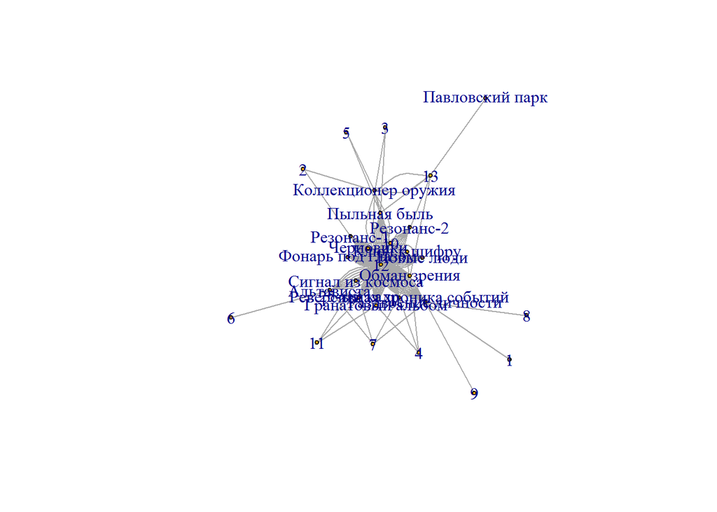

```r
graph_df <- subset(kw_with_cluster,select=c('album','cluster'))
g<-graph.data.frame(graph_df, directed=FALSE)

plot(g,vertex.size = 3,
     label.cex = 7,
     edge.arrow.size = .005)
```